# iag

#### Problem statement:

You are a data scientist at an analytics consulting firm, one of your new clients, ACME (a widget manufacturer), would like to understand what causes failures of widgets and how these can be predicted or prevented in the future. They have provided you with some data extracted from their mainframe system.

#### Data summary:

1. Failure: indicate whether the widget failed (=1) or not (=0)
2. The rest of the columns can be used as explanatory variables

#### Your tasks:

1. Explain your data science process in looking at this data and trying to solve the problem. Be as technical as you would like in your explanation.
2. Explain to your findings to the product owner at ACME and what they can do next.

```python
import pandas as pd
import numpy as np
import pylab as pl
%matplotlib inline
import seaborn as sns
```

```python
pl.rcParams['figure.figsize'] = (10,8)  # set figure size
pl.rcParams['figure.dpi'] = 100
pl.rc('font', size=10)
```

### 1. Exploratory data analysis

```python
# read data from csv to dataframe
data = pd.read_csv('modeldata.csv', header=0, low_memory=False, sep='|')
```

```python
print('Number of data samples: %s' % data.shape[0])
print('Number of data features: %s' % data.shape[1])
```

```
Number of data samples: 132224
Number of data features: 21
```

```python
data.isnull().sum()
```

```
failure          0
model            0
date             0
serial_number    0
smart_1_raw      0
smart_2_raw      0
smart_3_raw      0
smart_4_raw      0
smart_5_raw      0
smart_7_raw      0
smart_8_raw      0
smart_9_raw      0
smart_10_raw     0
smart_11_raw     0
smart_12_raw     0
smart_13_raw     0
smart_15_raw     0
smart_22_raw     0
smart_16_raw     0
smart_17_raw     0
smart_18_raw     0
dtype: int64
```

No missing values found in the dataset.

```python
data.failure.value_counts()
```

```
0    132019
1       205
Name: failure, dtype: int64
```

Failure events have 205 data samples, which account for 0.155% of all data. The dataset is highly imbalanced.

```python
data.model.value_counts()
```

```
ST4000DM000                70411
HGST HMS5C4040ALE640       14123
HGST HMS5C4040BLE640        9716
Hitachi HDS5C3030ALA630     9107
Hitachi HDS722020ALA330     9050
Hitachi HDS5C4040ALE630     5235
ST6000DX000                 3802
WDC WD30EFRX                2135
Hitachi HDS723030ALA640     2009
ST500LM012 HN               1410
WDC WD60EFRX                 954
WDC WD5000LPVX               616
ST4000DX000                  439
ST31500541AS                 437
WDC WD10EADS                 424
WDC WD20EFRX                 295
TOSHIBA MD04ABA400V          283
WDC WD1600AAJS               208
ST320LT007                   163
HGST HDS5C4040ALE630         148
ST9250315AS                  113
ST3160316AS                  102
ST3160318AS                   98
WDC WD40EFRX                  91
HGST HUH728080ALE600          90
HGST HDS724040ALE640          89
WDC WD10EACS                  89
TOSHIBA DT01ACA300            85
TOSHIBA MD04ABA500V           77
ST250LM004 HN                 69
                           ...
WDC WD2500BPVT                14
ST2000VN000                   13
WDC WD3200AAJS                 8
WDC WD2500AAJS                 8
WDC WD5002ABYS                 8
ST250LT007                     7
WDC WD800JB                    7
WDC WD800BB                    7
WDC WD1600BPVT                 5
ST4000DX002                    5
WDC WD3200AAKS                 3
WDC WD3200BEKT                 3
WDC WD3200AAJB                 3
Hitachi HDS5C3030BLE630        3
WDC WD15EARS                   3
Hitachi HDS724040ALE640        3
ST31500341AS                   3
WDC WD10EALS                   3
SAMSUNG HD154UI                2
WDC WD800LB                    2
WDC WD5003ABYX                 2
WDC WD2500BEVT                 2
WDC WD10EARS                   2
WDC WD1001FALS                 2
WDC WD10EARX                   1
WDC WD2500AAJB                 1
ST3500320AS                    1
Hitachi HDT725025VLA380        1
WDC WD3200LPVX                 1
WDC WD800JD                    1
Name: model, Length: 69, dtype: int64
```

Taking the feature model as an example, the total number is 69.

```python
data[data.failure==1].model.value_counts()
```

```
ST4000DM000                131
ST320LT007                  15
Hitachi HDS722020ALA330     13
WDC WD800AAJS                6
WDC WD30EFRX                 6
Hitachi HDS5C3030ALA630      5
Hitachi HDS5C4040ALE630      3
HGST HMS5C4040ALE640         2
ST4000DX000                  2
ST6000DX000                  2
ST3160318AS                  2
WDC WD20EFRX                 2
WDC WD10EADS                 2
WDC WD1600AAJS               2
WDC WD1600AAJB               2
ST3160316AS                  1
WDC WD800AAJB                1
TOSHIBA MD04ABA500V          1
WDC WD60EFRX                 1
WDC WD3200BEKX               1
WDC WD3200BEKT               1
TOSHIBA DT01ACA300           1
ST9250315AS                  1
HGST HMS5C4040BLE640         1
WDC WD800BB                  1
Name: model, dtype: int64
```

Failure events are from various models, which indicates model doesn't have discriminating power. So we don't use model as input in modelling.  
date and serial_number are also excluded from modelling.

```python
data.drop(['model', 'date', 'serial_number'], axis=1, inplace=True)
```

```python
data.std()
```

```
failure         3.934472e-02
smart_1_raw     7.854000e+07
smart_2_raw     4.635174e+01
smart_3_raw     1.110235e+03
smart_4_raw     1.296206e+02
smart_5_raw     1.017816e+02
smart_7_raw     0.000000e+00
smart_8_raw     1.824368e+01
smart_9_raw     1.288188e+04
smart_10_raw    2.715317e+03
smart_11_raw    2.904557e+01
smart_12_raw    4.773076e+01
smart_13_raw    4.616458e+00
smart_15_raw    0.000000e+00
smart_22_raw    2.608074e+00
smart_16_raw    2.242782e+00
smart_17_raw    7.065209e-01
smart_18_raw    8.082444e+02
dtype: float64
```

smart_7_raw and smart_15_raw have zero variance, so remove them.

```python
data.drop(['smart_7_raw', 'smart_15_raw'], axis=1, inplace=True)
```

```python
data.dtypes
```

```
failure           int64
smart_1_raw       int64
smart_2_raw       int64
smart_3_raw       int64
smart_4_raw       int64
smart_5_raw     float64
smart_8_raw       int64
smart_9_raw       int64
smart_10_raw      int64
smart_11_raw      int64
smart_12_raw      int64
smart_13_raw      int64
smart_22_raw      int64
smart_16_raw      int64
smart_17_raw      int64
smart_18_raw      int64
dtype: object
```

Now all features in the dataset are numerical, which are ready for modelling.

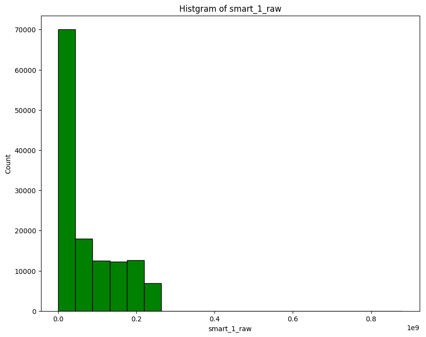

```python
_ = pl.hist(data.smart_1_raw, bins=20, color='green', edgecolor='black')
pl.xlabel('smart_1_raw')
pl.ylabel('Count')
pl.title('Histgram of smart_1_raw')
```

smart_1_raw is highly skewed, and most of observations are near 0.

```python
df = data[['failure', 'smart_1_raw']].copy()
```

```python
# create a new feature failure1
df['failure1'] = ['Failure' if i else 'No Failure' for i in df.failure.values]
```

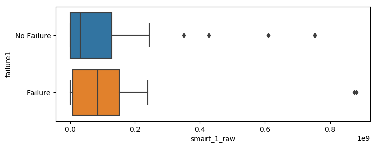

```python
# box plot: failure vs smart_1_raw
pl.figure(figsize=(8, 3))
sns.boxplot(x='smart_1_raw', y='failure1', data=df)
```

It is seen that failure events have greater smart_1_raw than non-failure events.

### 2. Modelling

As we already know that whether an event is failure or not, the problem can be considered as a binary classification task. The target variable is failure, and the others are used as input variables. Here random forest is employed.

```python
from sklearn.model_selection import train_test_split, GridSearchCV
from sklearn.ensemble import RandomForestClassifier
from sklearn.preprocessing import StandardScaler
from collections import Counter
from sklearn.metrics import accuracy_score, confusion_matrix, f1_score, recall_score
import itertools
```

```python
def preprocess(X, y):
    """
    Data preprocessing
        1. data split
        2. data standandization

    """

    trainX, testX, trainY, testY = train_test_split(X, y, test_size=0.3, random_state=0, stratify=y)
    print('Training data: %s' % Counter(trainY))
    print('Testing data: %s' % Counter(testY))

    s = StandardScaler()
    strain = s.fit_transform(trainX.values)
    stest = s.transform(testX.values)
    dftrain = pd.DataFrame(data=strain, index=trainX.index, columns=trainX.columns)
    dftest = pd.DataFrame(data=stest, index=testX.index, columns=testX.columns)

    return dftrain, dftest, trainY, testY

def evaluation(y_true, y_pred):
    # evaluate prediction result

    class_names = ['No Failure', 'Failure']
    conf_mat = confusion_matrix(y_true, y_pred)
    print('Accuracy: %.4f, Recall Score: %.4f' %
          (accuracy_score(y_true, y_pred), recall_score(y_true, y_pred)))
    plot_confusion_matrix(conf_mat, class_names)

def plot_confusion_matrix(cm, classes, normalize=False):
    """
    For a confusion matrix C, the element C_ij is equal to the number of observations
    known to be in label i but predicted to be in label j.

    """

    if normalize:
        cm = cm.astype('float') / cm.sum(axis=1)[:, np.newaxis]

    pl.imshow(cm, interpolation='nearest', cmap=pl.cm.Blues)
    pl.colorbar()
    tick_marks = np.arange(len(classes))

    fmt = '.2f' if normalize else 'd'
    thresh = cm.max() / 2.0
    for i, j in itertools.product(range(cm.shape[0]), range(cm.shape[1])):
        pl.text(j, i, format(cm[i, j], fmt),
                fontsize=11, horizontalalignment="center",
                color="white" if cm[i, j] > thresh else "black")
    pl.xticks(tick_marks, classes, fontsize=11)
    pl.yticks(tick_marks, classes, fontsize=11)
    pl.ylabel('True label', fontsize=13)
    pl.xlabel('Predicted label', fontsize=13)
    pl.tight_layout()
```

```python
X = data.drop('failure', axis=1)
y = data.failure
trainX, testX, trainY, testY = preprocess(X, y)
```

```
Training data: Counter({0: 92413, 1: 143})
Testing data: Counter({0: 39606, 1: 62})
```

As a common practice, 70% of data are used as training set, which are randomly chosen. And the rest 30% are used as testing set. The random forest model comes with default parameters.

```
Accuracy: 0.9996, Recall Score: 0.7742
```

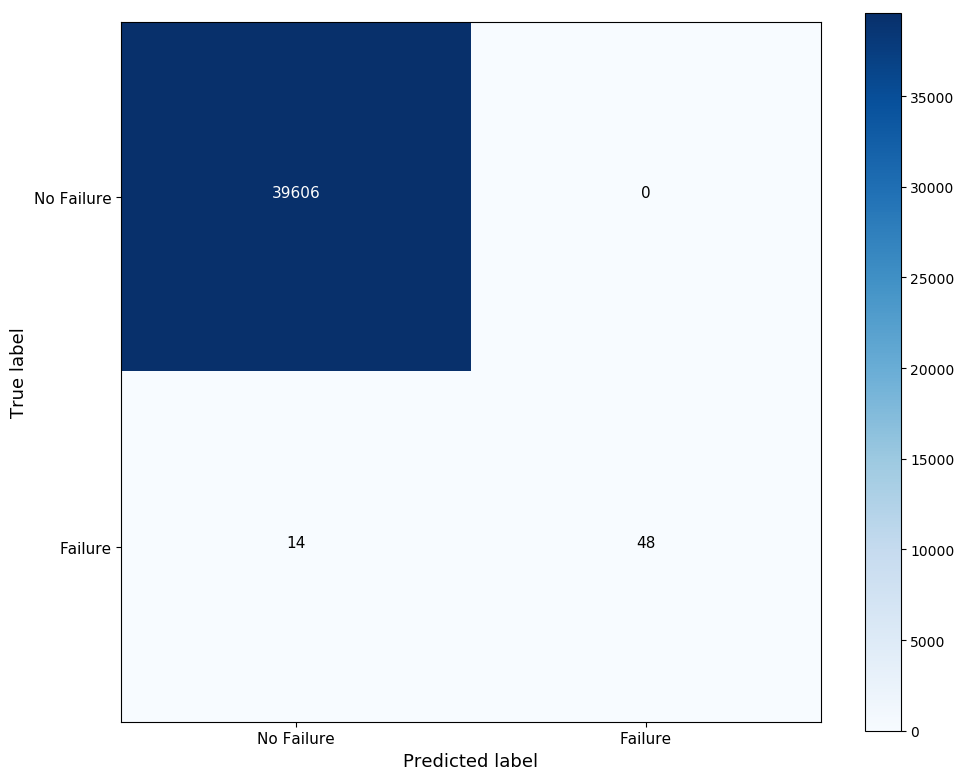

```python
# model build and prediction
m = RandomForestClassifier(random_state=42)
m.fit(trainX, trainY)
predY = m.predict(testX)
evaluation(testY, predY)
```

It is seen that the proposed model performs good in this case. The prediction accuray is 99.96% and the recall score is 77.42%. There are 14 failure events are wrongly predicted as no failure. All the no failure events are predicted correctly.

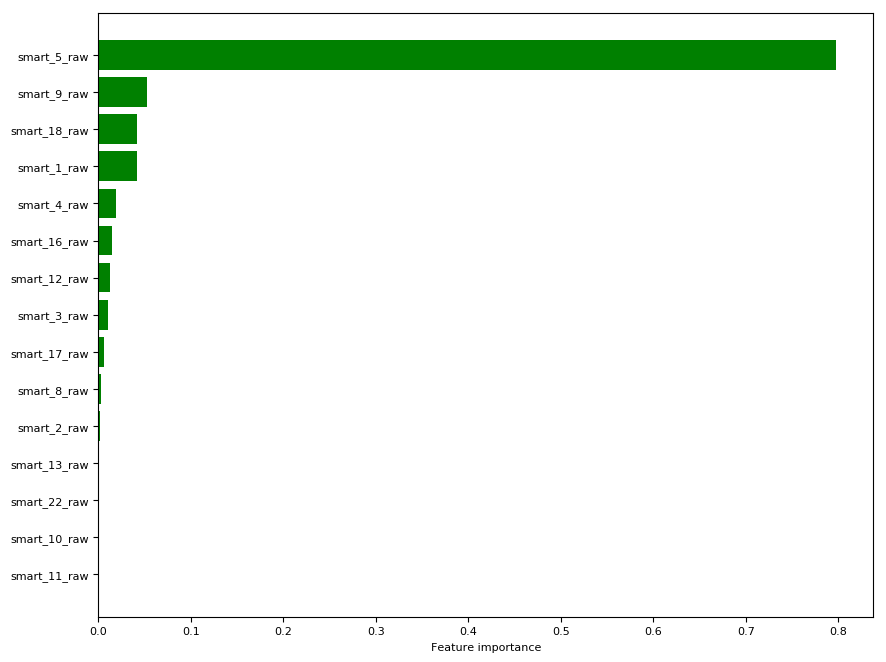

```python
# Check feature importances
features = X.columns.tolist()
features_importances = m.feature_importances_
indices = np.argsort(features_importances)

pl.barh(range(len(features)), features_importances[indices],color='green')
pl.yticks(range(len(features)), [features[i] for i in indices])
pl.xlabel('Feature importance', fontsize=8)
pl.tick_params(axis='both', labelsize=8)
```

One benefit from random forest model is that it can quantify the importance of features. As shown above, smart_5_raw, smart_9_raw, smart_18_raw are the top three in terms of feature importance. The top ranked features may be the causes of failure.

#### Undersampling for imbalanced classification

In previous model, we didn't consider the dataset is imbalanced, which is actually a big issue in classification. In real-world problem, we are more interested in failure events, as they may lead to critical business impact. Therefore, we want to identify as many failures as we can from the whole failure events. In other words, we prefer to increase the recall score, although this may cause a drop in accuracy score.

In this case, undersampling is considered to tackle the imbalance in dataset. The no failure events are under-sampled, and make the positive/negative ratio to be 1.

```python
from imblearn.under_sampling import RandomUnderSampler
```

```python
rus = RandomUnderSampler()
X_resampled, y_resampled = rus.fit_sample(trainX, trainY)
print('Training data: %s' % Counter(y_resampled))
```

```
Training data: Counter({0: 143, 1: 143})
```

```
Accuracy: 0.9875, Recall Score: 0.9194
```

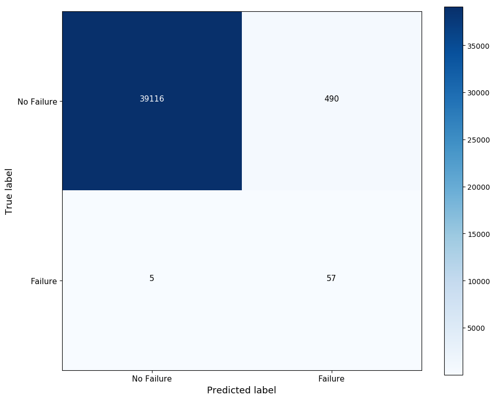

```python
m = RandomForestClassifier(random_state=42)
m.fit(X_resampled, y_resampled)
predY = m.predict(testX)
evaluation(testY, predY)
```

It is seen that the recall score increases from 0.7742 to 0.9194. Only 5 failures are not detected. In the meantime, 490 no failure events are predicted as failures, and the accuracy score decreases.

### 3. Conclusion

In this case study, the failure of widget is investigated. The detection of failure events is considered as a binary classification problem. Random forest is used in the modelling, and the performance is good. Moreover, random forecast is able to rank the importance of input features, which gives a shortlist of potential causes to the failure. In addition, as the dataset is highly imbalanced, undersampling is used to overcome this issue. It is shown that the recall score increases with undersampling.

#### Suggestions on next steps:

```
1. Collect more data.
2. Try more machine learning algorithms.
3. Fine-tune the model.
4. Feature selection and engineering.
5. Feed in domain knowledge.
```